# PREDICT_PARADIGM: 4. complete cases

Yuwei Wang

2023-07-12

# READ ME

# Load the libraries

```r
library("readxl")
library("readr")
library("dplyr")
library("plyr")
library("rms")
library("ggplot2")
library("timeROC")
library("stringr")
library("tidyverse")
```

# Load the complete dataset

```r
comp_df <- PRD %>%
  filter(age.start >= 25) %>%
  dplyr::select(palga_nr, age.start, screen, size, grade, nodes, er, pr, her2, ki67, delta, timeyr, gBRCA12, intrsub) %>%
  .[complete.cases(.$palga_nr, .$age.start, .$screen, .$size, .$grade, .$nodes, .$er, .$pr, .$her2, .$ki67, .$delta, .$timeyr),]
```

# Load functions

```r
validity_Fun <- function(data, time, status, predmort, tmax) {
      nwomen <- dim(data)[1]
      ntime <- length(tmax)
      res_validity <- c(nwomen)
      for (i in 1:ntime){

        surv_fit <- survfit(Surv(data[, time], data[, status]) ~ 1)

        #calculate the OE ratio
        obs_risk <- 1 - summary(surv_fit, times = tmax[i])$surv
        obs_se <- summary(surv_fit, times = tmax[i])$std.err
        nevent <- summary(surv_fit, times = tmax[i])$n.event
        exp_risk <- mean(data[, predmort[i]])


        OE_stats <- obs_risk / exp_risk
        se_OE_stats <- obs_se / exp_risk
        lowerCI_OE_stats <- round(OE_stats - qnorm(1 - 0.05/2) * se_OE_stats, 2)
        upperCI_OE_stats <- round(OE_stats + qnorm(1 - 0.05/2) * se_OE_stats, 2)

        res_OE <- paste0(round(OE_stats, 2), " (", lowerCI_OE_stats, "-", upperCI_OE_stats, ")")


        #calculate the AUC
        AUC <- timeROC(T = data[, time], delta = data[, status],
                       marker = data[, predmort[i]],
                       weighting = "marginal",
                       times = tmax[i], cause = 1, ROC = F, iid = T)
        AUC_stats <- AUC$AUC[2]
        se_AUC_stats <- AUC$inference$vect_sd_1 [2]
        lowerCI_AUC_stats <- round(AUC_stats - qnorm(1 - 0.05/2) * se_AUC_stats, 2)
        upperCI_AUC_stats <- round(AUC_stats + qnorm(1 - 0.05/2) * se_AUC_stats, 2)

        res_AUC <- paste0(round(AUC_stats, 2), " (", lowerCI_AUC_stats, "-", upperCI_AUC_stats, ")")


        res_validity <- append(res_validity, c(nevent, res_OE, res_AUC))

      }
      return(res_validity)
}
```

```r
caliplot_df <- function(data, time, status, predmort, tmax) {

    q5 <- cut(data[, predmort],
              breaks = quantile(data[, predmort], probs = seq(0, 1, 0.20)), include.lowest = TRUE)

    data$risk_q5 <- factor(q5, levels = levels(q5), labels = c('q1', 'q2', 'q3', 'q4', "q5"))

    exp_risk <- tapply(data[, predmort], data[, "risk_q5"], mean)

    surv_fit <- survfit(Surv(data[, time], data[, status]) ~ data[, "risk_q5"])

    obs_risk <- 1 - summary(surv_fit ,times = tmax)$surv
    obs_se <- summary(surv_fit ,times = tmax)$std.err

    obs_lower <- obs_risk - qnorm(1 - 0.05/2) * obs_se
    obs_upper <- obs_risk + qnorm(1 - 0.05/2) * obs_se


    caliplot_data <- cbind(obs_risk, obs_lower, obs_upper, exp_risk) %>%
      as.data.frame(.)
    names(caliplot_data) <- c("obs.y", "obs.lower", "obs.upper", "exp.x")

    return(caliplot_data)
}
```

# Run the script

## PREDICT V2.2

Note that PREDICTv2.2 published on https://github.com/gmp26/v22/blob/master/R/v22_model.R was slightly different. 1. PREDICTv2.2 allows missing values in grade (if missing, impute missingness with 2.13) and screening (if missing, impute missingness with 0.204). In my script, grade is not allowed to be missing, the same as the PREDICT published on their website. For screening, we expect very few women in our cohort who would undergo screening, as they were all under 40 years at diagnosis. Screening for BRCA1/2 carriers was not yet inplemented before 2000. 2. PREDICTv2.2 on the github added several codes about radiotherapy. However, these codes are currently disabled thus not being used right now. 3. PREDICTv2.2 on the github included systemic treatment. I deleted these part because all women in our cohort were adjuvant treatment-naive.

```r
for (n in 1:nrow(comp_df)) {
  # Input case characteristics
  age.start  <- comp_df$age.start[n]
  screen     <- comp_df$screen[n]     # Clinically detected = 0, screen detected = 1
  size       <- comp_df$size[n]   # Tumour size mm
  grade      <- comp_df$grade[n]     # Tumour grade
  nodes      <- comp_df$nodes[n]     # Number positive nodes. Nodal micrometastases = 0.5
  er         <- comp_df$er[n]     # ER+ = 1, ER- = 0
  her2       <- comp_df$her2[n]     # HER2+ = 1, HER2- = 0, missing = 9
  ki67       <- comp_df$ki67[n]     # KI67+ = 1, KI67- = 0, missing = 9

  # Grade variable for ER neg
  grade.val <- ifelse(er==1, grade, ifelse(grade==1, 0, 1))

  # Generate the coefficients
  age.mfp.1   <- ifelse(er==1, (age.start/10)^-2-.0287449295, age.start-56.3254902)
  age.beta.1  <- ifelse(er==1, 34.53642, 0.0089827)
  age.mfp.2   <- ifelse(er==1, (age.start/10)^-2*log(age.start/10)-.0510121013, 0)
  age.beta.2  <- ifelse(er==1, -34.20342, 0)
  size.mfp    <- ifelse(er==1, log(size/100)+1.545233938, (size/100)^.5-.5090456276)
  size.beta   <- ifelse(er==1, 0.7530729, 2.093446)
  nodes.mfp   <- ifelse(er==1,log((nodes+1)/10)+1.387566896,
                        log((nodes+1)/10)+1.086916249)
  nodes.beta  <- ifelse(er==1, 0.7060723, .6260541)
  grade.beta  <- ifelse(er==1, 0.746655, 1.129091)
  screen.beta <- ifelse(er==1, -0.22763366, 0)
  her2.beta   <- ifelse(her2==1, 0.2413,
                        ifelse(her2==0, -0.0762, 0))
  ki67.beta   <- ifelse(ki67==1 & er==1, 0.14904,
                        ifelse(ki67==0 & er==1, -0.1133, 0))

  # Calculate the other and breast mortality indicies

  # Other mortality prognostic index (mi)
  mi <- 0.0698252*((age.start/10)^2-34.23391957)

  # Breast cancer mortality prognostic index (pi)
  pi <- age.beta.1*age.mfp.1 + age.beta.2*age.mfp.2 + size.beta*size.mfp +
    nodes.beta*nodes.mfp + grade.beta*grade.val + screen.beta*screen +
    her2.beta + ki67.beta

  # Non breast cancer mortality
  # Generate cumulative baseline other mortality

  time<-c(5,10,15)

  base.m.cum.oth <- exp(-6.052919 + (1.079863*log(time)) + (.3255321*time^.5))


  # Generate cumulative survival non-breast mortality
  #YW: cumulative non-breast cancer survival
  s.cum.oth <- exp(-exp(mi)*base.m.cum.oth)

  # Generate annual survival from cumulative survival
  #YW: cumulative non-breast cancer mortality
  m.cum.oth <- 1 - s.cum.oth

  # Breast cancer specific mortality
  # Generate cumulative baseline breast mortality
  if (er==1) {
    base.m.cum.br <- exp(0.7424402 - 7.527762/time^.5 - 1.812513*log(time)/time^.5)
  } else { base.m.cum.br <- exp(-1.156036 + 0.4707332/time^2 - 3.51355/time)
  }
  # Calculate the cumulative breast cancer survival
  s.cum.br <- exp(-exp(pi)*base.m.cum.br)
  m.cum.br <- 1 - s.cum.br

  # All cause mortality
  m.cum.all <- 1 - s.cum.oth*s.cum.br
  s.cum.all <- 100-100*m.cum.all

  # Proportion of all cause mortality that is breast cancer
  prop.br <- m.cum.br/(m.cum.br+m.cum.oth)
  prop.oth <- m.cum.oth/(m.cum.br+m.cum.oth)
  # Predicted cumulative breast specific mortality
  pred.m.br    <- prop.br*m.cum.all
  # Predicted cumulative non-breast cancer mortality
  pred.m.oth <- prop.oth*m.cum.all
  # Predicted cumulative all-cause mortality
  pred.all <- pred.m.br + pred.m.oth #pred.all=m.cum.all

  # Predicted all cause mortality
  comp_df$v22_all5[n] <- pred.all[1]
  comp_df$v22_all10[n] <- pred.all[2]
  comp_df$v22_all15[n] <- pred.all[3]


  #prognostic index, this is not related to time
  comp_df$v22_pi[n] <- pi #larger pi is associated with higher risks of events

}
```

## PREDICT V2.3

PREDICT v2.3 was not yet published. The information on the predictor PR was derived from the manuscript from Grootes et al. 2022.

```r
for (n in 1:nrow(comp_df)) {
  # Input case characteristics
  age.start  <- comp_df$age.start[n]
  screen     <- comp_df$screen[n]     # Clinically detected = 0, screen detected = 1
  size       <- comp_df$size[n]   # Tumour size mm
  grade      <- comp_df$grade[n]     # Tumour grade
  nodes      <- comp_df$nodes[n]     # Number positive nodes. Nodal micrometastases = 0.5
  er         <- comp_df$er[n]     # ER+ = 1, ER- = 0
  her2       <- comp_df$her2[n]     # HER2+ = 1, HER2- = 0, missing = 9
  ki67       <- comp_df$ki67[n]     # KI67+ = 1, KI67- = 0, missing = 9
  pr       <- comp_df$pr[n]
  # Grade variable for ER neg
  grade.val <- ifelse(er==1, grade, ifelse(grade==1, 0, 1))

  # Generate the coefficients
  age.mfp.1   <- ifelse(er==1, (age.start/10)^-2-.0287449295, age.start-56.3254902)
  age.beta.1  <- ifelse(er==1, 34.53642, 0.0089827)
  age.mfp.2   <- ifelse(er==1, (age.start/10)^-2*log(age.start/10)-.0510121013, 0)
  age.beta.2  <- ifelse(er==1, -34.20342, 0)
  size.mfp    <- ifelse(er==1, log(size/100)+1.545233938, (size/100)^.5-.5090456276)
  size.beta   <- ifelse(er==1, 0.7530729, 2.093446)
  nodes.mfp   <- ifelse(er==1,log((nodes+1)/10)+1.387566896,
                        log((nodes+1)/10)+1.086916249)
  nodes.beta  <- ifelse(er==1, 0.7060723, .6260541)
  grade.beta  <- ifelse(er==1, 0.746655, 1.129091)
  screen.beta <- ifelse(er==1, -0.22763366, 0)
  her2.beta   <- ifelse(her2==1, 0.2413,
                        ifelse(her2==0, -0.0762, 0))
  ki67.beta   <- ifelse(ki67==1 & er==1, 0.14904,
                        ifelse(ki67==0 & er==1, -0.1133, 0))
  pr.beta     <- ifelse(pr == 1 & er == 1, -0.0618754,
                      ifelse(pr == 0 & er == 1, 0.2623643,
                             ifelse(pr == 1 & er == 0, -0.2231436, 0.0295588)))

  # Calculate the other and breast mortality indicies

  # Other mortality prognostic index (mi)
  mi <- 0.0698252*((age.start/10)^2-34.23391957)

  # Breast cancer mortality prognostic index (pi)
  pi <- age.beta.1*age.mfp.1 + age.beta.2*age.mfp.2 + size.beta*size.mfp +
    nodes.beta*nodes.mfp + grade.beta*grade.val + screen.beta*screen +
    her2.beta + ki67.beta + pr.beta

  # Non breast cancer mortality
  # Generate cumulative baseline other mortality

  time<-c(5,10,15)

  base.m.cum.oth <- exp(-6.052919 + (1.079863*log(time)) + (.3255321*time^.5))


  # Generate cumulative survival non-breast mortality
  #YW: cumulative non-breast cancer survival
  s.cum.oth <- exp(-exp(mi)*base.m.cum.oth)

  # Generate annual survival from cumulative survival
  #YW: cumulative non-breast cancer mortality
  m.cum.oth <- 1 - s.cum.oth

  # Breast cancer specific mortality
  # Generate cumulative baseline breast mortality
  if (er==1) {
    base.m.cum.br <- exp(0.7424402 - 7.527762/time^.5 - 1.812513*log(time)/time^.5)
  } else { base.m.cum.br <- exp(-1.156036 + 0.4707332/time^2 - 3.51355/time)
  }
  # Calculate the cumulative breast cancer survival
  s.cum.br <- exp(-exp(pi)*base.m.cum.br)
  m.cum.br <- 1 - s.cum.br

  # All cause mortality
  m.cum.all <- 1 - s.cum.oth*s.cum.br
  s.cum.all <- 100-100*m.cum.all

  # Proportion of all cause mortality that is breast cancer
  prop.br <- m.cum.br/(m.cum.br+m.cum.oth)
  prop.oth <- m.cum.oth/(m.cum.br+m.cum.oth)
  # Predicted cumulative breast specific mortality
  pred.m.br    <- prop.br*m.cum.all
  # Predicted cumulative non-breast cancer mortality
  pred.m.oth <- prop.oth*m.cum.all
  # Predicted cumulative all-cause mortality
  pred.all <- pred.m.br + pred.m.oth #pred.all=m.cum.all

  # Predicted all cause mortality
  comp_df$v23_all5[n] <- pred.all[1]
  comp_df$v23_all10[n] <- pred.all[2]
  comp_df$v23_all15[n] <- pred.all[3]


  #prognostic index, this is not related to time
  comp_df$v23_pi[n] <- pi #larger pi is associated with higher risks of events

}
```

# Calibration and discrimination

## PREDICT V2.2

```r
res_v22_all <- validity_Fun(data = comp_df, time = "timeyr", status = "delta",
                         predmort = c("v22_all5", "v22_all10", "v22_all15"), tmax = c(5, 10, 15))

res_v22_ERpos <- validity_Fun(data = filter(comp_df, comp_df$er == 1), time = "timeyr", status = "delta",
                         predmort = c("v22_all5", "v22_all10", "v22_all15"), tmax = c(5, 10, 15))

res_v22_ERneg <- validity_Fun(data = filter(comp_df, comp_df$er == 0), time = "timeyr", status = "delta",
                         predmort = c("v22_all5", "v22_all10", "v22_all15"), tmax = c(5, 10, 15))

res_v22_HRposHER2neg <- validity_Fun(data = filter(comp_df, comp_df$intrsub == "HRposHER2neg"), time = "timeyr",
                                  status = "delta", predmort = c("v22_all5", "v22_all10", "v22_all15"), tmax = c(5, 10, 15))
res_v22_HRposHER2pos <- validity_Fun(data = filter(comp_df, comp_df$intrsub == "HRposHER2pos"), time = "timeyr",
                                  status = "delta", predmort = c("v22_all5", "v22_all10", "v22_all15"), tmax = c(5, 10, 15))
res_v22_HRnegHER2pos <- validity_Fun(data = filter(comp_df, comp_df$intrsub == "HRnegHER2pos"), time = "timeyr",
                                  status = "delta", predmort = c("v22_all5", "v22_all10", "v22_all15"), tmax = c(5, 10, 15))
res_v22_HRnegHER2neg <- validity_Fun(data = filter(comp_df, comp_df$intrsub == "HRnegHER2neg"), time = "timeyr",
                                  status = "delta", predmort = c("v22_all5", "v22_all10", "v22_all15"), tmax = c(5, 10, 15))


res_v22_HRnegHER2neg_gBRCA12m <- validity_Fun(data = filter(comp_df, comp_df$intrsub == "HRnegHER2neg" & comp_df$gBRCA12 == 1), time = "timeyr",
                                  status = "delta", predmort = c("v22_all5", "v22_all10", "v22_all15"), tmax = c(5, 10, 15))

res_v22_HRnegHER2neg_gBRCA12wt <- validity_Fun(data = filter(comp_df, comp_df$intrsub == "HRnegHER2neg" & comp_df$gBRCA12 == 0), time = "timeyr",
                                  status = "delta", predmort = c("v22_all5", "v22_all10", "v22_all15"), tmax = c(5, 10, 15))



res_v22 <- matrix(c(res_v22_all, res_v22_ERpos, res_v22_ERneg, res_v22_HRposHER2neg, res_v22_HRposHER2pos,
                    res_v22_HRnegHER2pos, res_v22_HRnegHER2neg, res_v22_HRnegHER2neg_gBRCA12m, res_v22_HRnegHER2neg_gBRCA12wt),
                      nrow = 9, byrow = T,
                      dimnames = list(c("All women", "ER-positive", "ER-negative", "HRposHER2neg", "HRposHER2pos",
                                        "HRnegHER2pos", "HRnegHER2neg","gBRCA12m", "gBRCA12wt"),
                                      c("No. women", "event_5","OE_5", "AUC_5", "event_10","OE_10", "AUC_10",
                                        "event_15","OE_15", "AUC_15"))) %>%
  as.data.frame(.)

res_v22
```

```
##              No. women event_5             OE_5            AUC_5 event_10
## All women         1698     211 1.43 (1.25-1.61) 0.72 (0.69-0.76)      374
## ER-positive       1210     104  1.5 (1.22-1.77) 0.73 (0.68-0.78)      249
## ER-negative        488     107  1.37 (1.14-1.6) 0.58 (0.52-0.64)      125
## HRposHER2neg      1021      70  1.3 (1.01-1.59) 0.73 (0.67-0.79)      179
## HRposHER2pos       212      40  2.1 (1.52-2.69) 0.62 (0.53-0.71)       76
## HRnegHER2pos        74      20  1.4 (0.88-1.92)   0.55 (0.4-0.7)       24
## HRnegHER2neg       391      81 1.35 (1.09-1.61) 0.56 (0.49-0.63)       95
## gBRCA12m            87      22 1.61 (1.03-2.19) 0.52 (0.38-0.66)       26
## gBRCA12wt          251      48 1.24 (0.93-1.56)  0.59 (0.5-0.68)       54
##                         OE_10           AUC_10 event_15            OE_15
## All women    1.34 (1.22-1.46) 0.65 (0.62-0.68)      474 1.21 (1.12-1.31)
## ER-positive  1.45 (1.29-1.61) 0.69 (0.65-0.72)      337 1.27 (1.15-1.38)
## ER-negative  1.15 (0.98-1.33)  0.56 (0.5-0.62)      137  1.1 (0.94-1.25)
## HRposHER2neg 1.36 (1.18-1.54) 0.69 (0.64-0.73)      258  1.26 (1.13-1.4)
## HRposHER2pos 1.69 (1.38-1.99) 0.55 (0.47-0.63)       86 1.28 (1.07-1.48)
## HRnegHER2pos 1.22 (0.82-1.62)  0.5 (0.36-0.64)       25 1.12 (0.76-1.48)
## HRnegHER2neg 1.13 (0.93-1.33) 0.54 (0.47-0.61)      105 1.09 (0.91-1.26)
## gBRCA12m     1.37 (0.93-1.81)  0.54 (0.4-0.67)       30 1.37 (0.97-1.77)
## gBRCA12wt       1 (0.76-1.24) 0.57 (0.49-0.66)       59 0.95 (0.74-1.16)
##                        AUC_15
## All women    0.64 (0.61-0.67)
## ER-positive   0.67 (0.64-0.7)
## ER-negative  0.56 (0.51-0.62)
## HRposHER2neg  0.67 (0.63-0.7)
## HRposHER2pos 0.56 (0.48-0.64)
## HRnegHER2pos  0.54 (0.4-0.68)
## HRnegHER2neg 0.54 (0.48-0.61)
## gBRCA12m     0.54 (0.41-0.68)
## gBRCA12wt    0.56 (0.48-0.65)
```

## PREDICT V2.3

```r
res_v23_all <- validity_Fun(data = comp_df, time = "timeyr", status = "delta",
                         predmort = c("v23_all5", "v23_all10", "v23_all15"), tmax = c(5, 10, 15))

res_v23_ERpos <- validity_Fun(data = filter(comp_df, comp_df$er == 1), time = "timeyr", status = "delta",
                         predmort = c("v23_all5", "v23_all10", "v23_all15"), tmax = c(5, 10, 15))

res_v23_ERneg <- validity_Fun(data = filter(comp_df, comp_df$er == 0), time = "timeyr", status = "delta",
                         predmort = c("v23_all5", "v23_all10", "v23_all15"), tmax = c(5, 10, 15))

res_v23_HRposHER2neg <- validity_Fun(data = filter(comp_df, comp_df$intrsub == "HRposHER2neg"), time = "timeyr",
                                  status = "delta", predmort = c("v23_all5", "v23_all10", "v23_all15"), tmax = c(5, 10, 15))
res_v23_HRposHER2pos <- validity_Fun(data = filter(comp_df, comp_df$intrsub == "HRposHER2pos"), time = "timeyr",
                                  status = "delta", predmort = c("v23_all5", "v23_all10", "v23_all15"), tmax = c(5, 10, 15))
res_v23_HRnegHER2pos <- validity_Fun(data = filter(comp_df, comp_df$intrsub == "HRnegHER2pos"), time = "timeyr",
                                  status = "delta", predmort = c("v23_all5", "v23_all10", "v23_all15"), tmax = c(5, 10, 15))
res_v23_HRnegHER2neg <- validity_Fun(data = filter(comp_df, comp_df$intrsub == "HRnegHER2neg"), time = "timeyr",
                                  status = "delta", predmort = c("v23_all5", "v23_all10", "v23_all15"), tmax = c(5, 10, 15))


res_v23_HRnegHER2neg_gBRCA12m <- validity_Fun(data = filter(comp_df, comp_df$intrsub == "HRnegHER2neg" & comp_df$gBRCA12 == 1), time = "timeyr",
                                  status = "delta", predmort = c("v23_all5", "v23_all10", "v23_all15"), tmax = c(5, 10, 15))

res_v23_HRnegHER2neg_gBRCA12wt <- validity_Fun(data = filter(comp_df, comp_df$intrsub == "HRnegHER2neg" & comp_df$gBRCA12 == 0), time = "timeyr",
                                  status = "delta", predmort = c("v23_all5", "v23_all10", "v23_all15"), tmax = c(5, 10, 15))



res_v23 <- matrix(c(res_v23_all, res_v23_ERpos, res_v23_ERneg, res_v23_HRposHER2neg, res_v23_HRposHER2pos,
                    res_v23_HRnegHER2pos, res_v23_HRnegHER2neg, res_v23_HRnegHER2neg_gBRCA12m, res_v23_HRnegHER2neg_gBRCA12wt),
                      nrow = 9, byrow = T,
                      dimnames = list(c("All women", "ER-positive", "ER-negative", "HRposHER2neg", "HRposHER2pos",
                                        "HRnegHER2pos", "HRnegHER2neg","gBRCA12m", "gBRCA12wt"),
                                      c("No. women", "event_5","OE_5", "AUC_5", "event_10","OE_10", "AUC_10",
                                        "event_15","OE_15", "AUC_15"))) %>%
  as.data.frame(.)

res_v23
```

```
##              No. women event_5             OE_5            AUC_5 event_10
## All women         1698     211  1.42 (1.24-1.6) 0.73 (0.69-0.76)      374
## ER-positive       1210     104  1.5 (1.22-1.77) 0.73 (0.68-0.78)      249
## ER-negative        488     107 1.35 (1.13-1.58) 0.57 (0.51-0.63)      125
## HRposHER2neg      1021      70 1.31 (1.02-1.61) 0.73 (0.67-0.79)      179
## HRposHER2pos       212      40  2.1 (1.51-2.68) 0.63 (0.54-0.72)       76
## HRnegHER2pos        74      20 1.36 (0.85-1.87)   0.55 (0.4-0.7)       24
## HRnegHER2neg       391      81 1.31 (1.06-1.57) 0.56 (0.49-0.63)       95
## gBRCA12m            87      22    1.57 (1-2.14) 0.52 (0.38-0.66)       26
## gBRCA12wt          251      48  1.21 (0.9-1.52)  0.59 (0.5-0.68)       54
##                         OE_10           AUC_10 event_15            OE_15
## All women    1.33 (1.21-1.45) 0.65 (0.62-0.68)      474  1.21 (1.12-1.3)
## ER-positive  1.45 (1.29-1.61) 0.69 (0.65-0.72)      337 1.27 (1.15-1.38)
## ER-negative  1.14 (0.96-1.31)  0.56 (0.5-0.61)      137 1.08 (0.93-1.24)
## HRposHER2neg 1.37 (1.19-1.56) 0.69 (0.65-0.73)      258 1.27 (1.14-1.41)
## HRposHER2pos 1.68 (1.38-1.98) 0.55 (0.47-0.63)       86 1.28 (1.07-1.48)
## HRnegHER2pos  1.19 (0.8-1.59)  0.5 (0.36-0.64)       25 1.09 (0.75-1.44)
## HRnegHER2neg  1.11 (0.91-1.3) 0.54 (0.47-0.61)      105 1.06 (0.89-1.23)
## gBRCA12m      1.33 (0.9-1.76)  0.54 (0.4-0.67)       30 1.34 (0.95-1.73)
## gBRCA12wt    0.98 (0.75-1.21) 0.57 (0.49-0.66)       59 0.93 (0.72-1.13)
##                        AUC_15
## All women    0.64 (0.61-0.67)
## ER-positive   0.67 (0.63-0.7)
## ER-negative   0.56 (0.5-0.61)
## HRposHER2neg  0.66 (0.63-0.7)
## HRposHER2pos 0.57 (0.49-0.64)
## HRnegHER2pos  0.54 (0.4-0.68)
## HRnegHER2neg 0.54 (0.48-0.61)
## gBRCA12m     0.54 (0.41-0.68)
## gBRCA12wt    0.56 (0.48-0.65)
```

# Calibration plot

```r
calplot10_df_v22_all <- caliplot_df(data = comp_df, time= "timeyr", status = "delta", predmort = "v22_all10", tmax = 10)
calplot10_df_v22_ERpos <- caliplot_df(data = filter(comp_df, comp_df$er == 1),
                                   time= "timeyr", status = "delta", predmort = "v22_all10", tmax = 10)
calplot10_df_v22_ERneg <- caliplot_df(data = filter(comp_df, comp_df$er == 0),
                                   time= "timeyr", status = "delta", predmort = "v22_all10", tmax = 10)
```

## All women

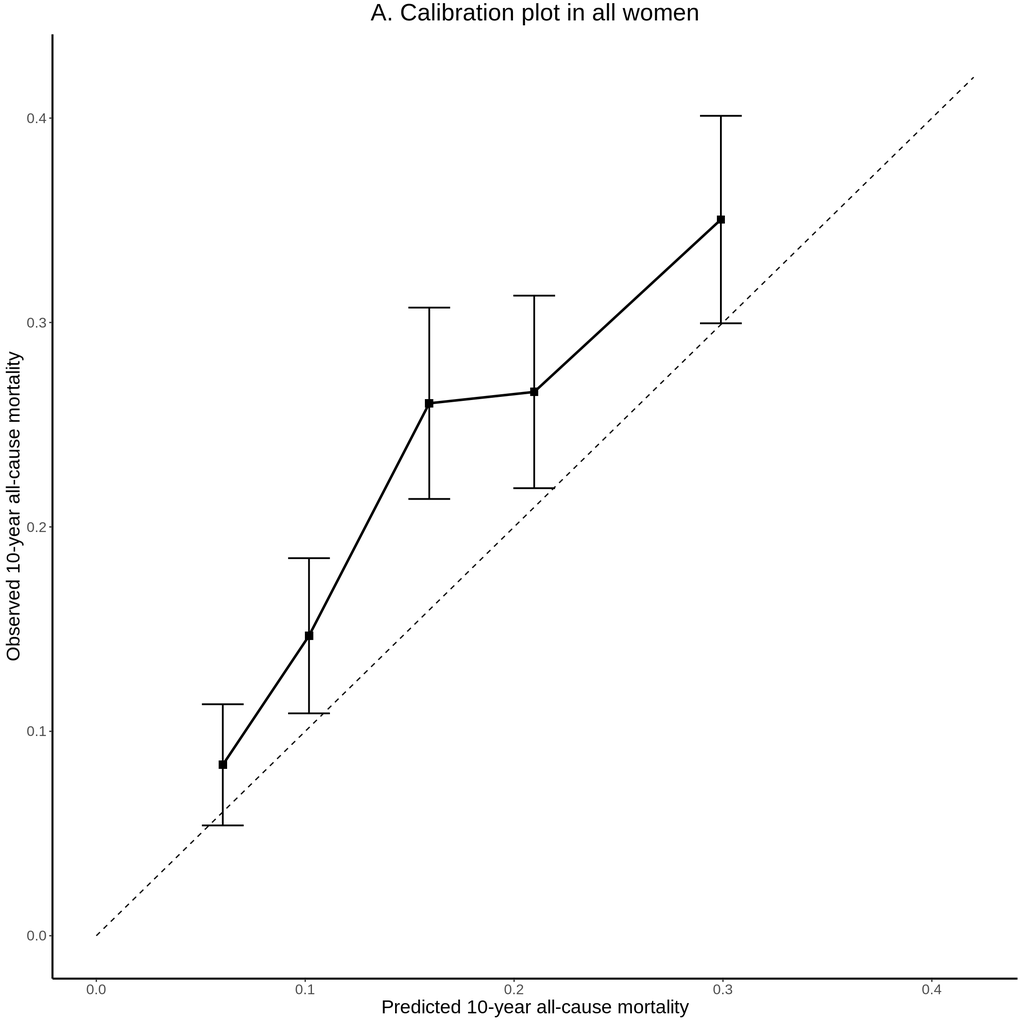

```r
caliplot_v22_all <-
  ggplot(calplot10_df_v22_all, aes(x = exp.x, y = obs.y)) +
  geom_point(color = "black", size = 3, shape = 15) +
  geom_line(color = "black", size = 1) +
  #abline! I used geomline instead of abline because I could specify the length of the abline
  geom_line(data = data.frame(x = c(0, 0.42), y = c(0, 0.42)),
            aes(x, y), color = "black", linetype = "dashed") +
  geom_errorbar(aes(ymin = obs.lower, ymax = obs.upper),
                width = 0.02, color = "black", size = 0.7) +
  #geom_vline(xintercept = 0.12, color = "red", linetype = "dashed") +
  xlim(0, 0.42) + ylim(0, 0.42) +
  xlab("Predicted 10-year all-cause mortality") +
  ylab("Observed 10-year all-cause mortality") +
  ggtitle("A. Calibration plot in all women") +
  theme(plot.title = element_text(hjust = 0.5, vjust = 1.5, size = 20),
        text = element_text(family = "Arial"),
        panel.background = element_rect(fill = "white"),
        axis.title = element_text(size = 16),
        axis.line = element_line(color = "black", linewidth = 0.8),
        axis.text = element_text(size = 12))
caliplot_v22_all
```

## Women with ER-positive tumors

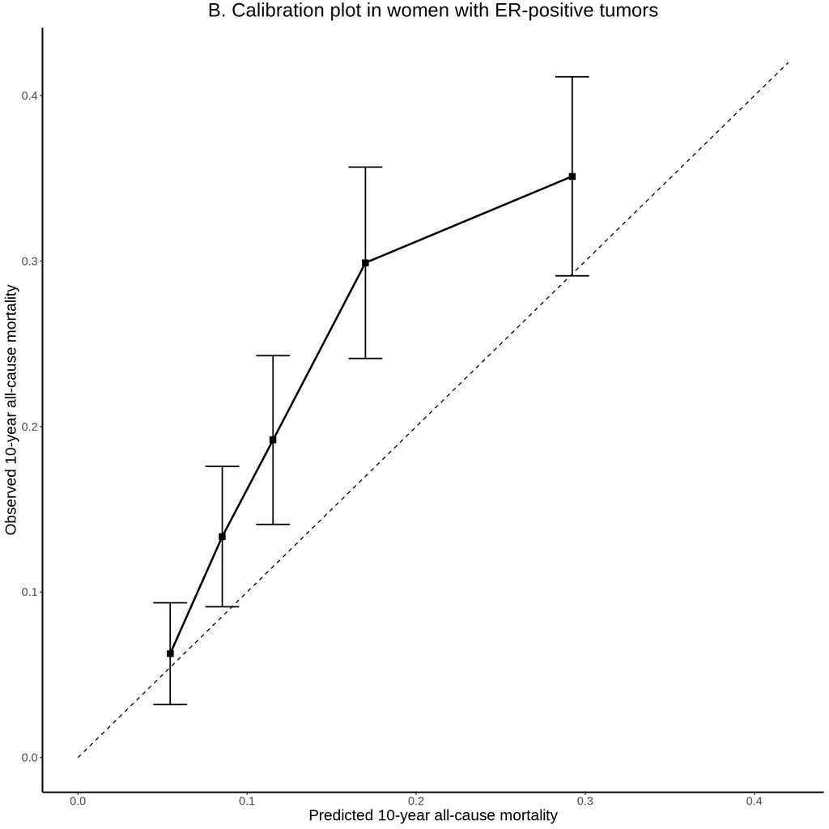

```r
caliplot_v22_ERpos <-
  ggplot(calplot10_df_v22_ERpos, aes(x = exp.x, y = obs.y)) +
  geom_point(color = "black", size = 3, shape = 15) +
  geom_line(color = "black", size = 1) +
  #abline! I used geomline instead of abline because I could specify the length of the abline
  geom_line(data = data.frame(x = c(0, 0.42), y = c(0, 0.42)),
            aes(x, y), color = "black", linetype = "dashed") +
  geom_errorbar(aes(ymin = obs.lower, ymax = obs.upper),
                width = 0.02, color = "black", size = 0.7) +
  #geom_vline(xintercept = 0.12, color = "red", linetype = "dashed") +
  xlim(0, 0.42) + ylim(0, 0.42) +
  xlab("Predicted 10-year all-cause mortality") +
  ylab("Observed 10-year all-cause mortality") +
  ggtitle("B. Calibration plot in women with ER-positive tumors") +
  theme(plot.title = element_text(hjust = 0.5, vjust = 1.5, size = 20),
        text = element_text(family = "Arial"),
        panel.background = element_rect(fill = "white"),
        axis.title = element_text(size = 16),
        axis.line = element_line(color = "black", linewidth = 0.8),
        axis.text = element_text(size = 12))
caliplot_v22_ERpos
```

## Women with ER-negative tumors

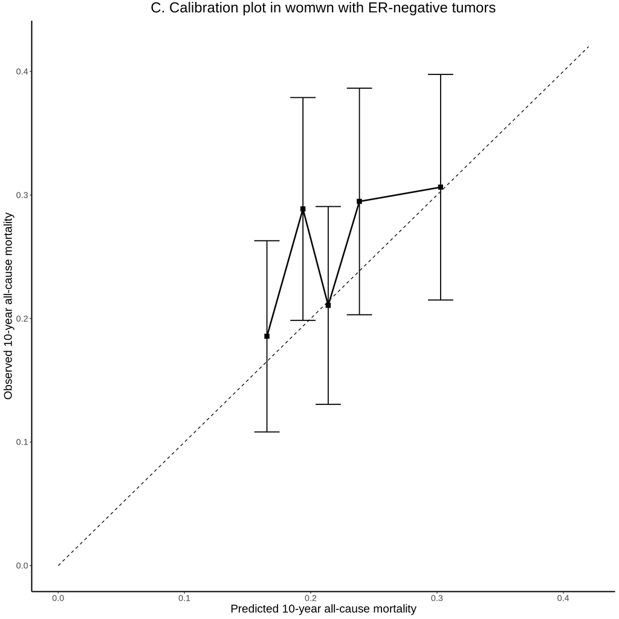

```r
caliplot_v22_ERneg <-
  ggplot(calplot10_df_v22_ERneg, aes(x = exp.x, y = obs.y)) +
  geom_point(color = "black", size = 3, shape = 15) +
  geom_line(color = "black", size = 1) +
  #abline! I used geomline instead of abline because I could specify the length of the abline
  geom_line(data = data.frame(x = c(0, 0.42), y = c(0, 0.42)),
            aes(x, y), color = "black", linetype = "dashed") +
  geom_errorbar(aes(ymin = obs.lower, ymax = obs.upper),
                width = 0.02, color = "black", size = 0.7) +
  #geom_vline(xintercept = 0.12, color = "red", linetype = "dashed") +
  xlim(0, 0.42) + ylim(0, 0.42) +
  xlab("Predicted 10-year all-cause mortality") +
  ylab("Observed 10-year all-cause mortality") +
  ggtitle("C. Calibration plot in womwn with ER-negative tumors") +
  theme(plot.title = element_text(hjust = 0.5, vjust = 1.5, size = 20),
        text = element_text(family = "Arial"),
        panel.background = element_rect(fill = "white"),
        axis.title = element_text(size = 16),
        axis.line = element_line(color = "black", linewidth = 0.8),
        axis.text = element_text(size = 12))
caliplot_v22_ERneg
```